# Data Science Using Python, SAS, & R:

A Rosetta Stone for Analytical Languages

# SAS Tutorial

Welcome to the SAS tutorial version of “Data Science Using Python, SAS, & R: A Rosetta Stone for Analytical Languages”. This tutorial includes examples of common data science tasks, organized in the same way across 3 data science languages. Before beginning this tutorial, please check to make sure you have SAS 14.2 installed (this is not required, but this is the release used to generate the following examples). SAS Enterprise Miner Workstation 14.2 was used to produce some of the following results.

You also may need to insure that your [SAS environment is connected with an R environment](https://communities.sas.com/t5/General-SAS-Programming/Run-R-code-inside-SAS-easily/td-p/210116) so that the R code that SAS calls at the end of this tutorial from the IML Procedure runs successfully.

Note: In SAS,

```sas
*  This is a single line comment ;
/* This is a paragraph
   comment */
```

Now let’s get started!

# 1 Reading in Data and Basic Statistical Functions

## 1.1 Read in the data.

The IMPORT Procedure is useful for reading in SAS data sets of a variety of different types.

### a) Read the data in as a .csv file.

```sas
proc import out = student
  datafile = 'C:/Users/class.csv'
  dbms = csv replace;
  getnames = yes;
run;
```

### b) Read the data in as a .xls file.

```sas
proc import out = student_xls
  datafile = 'C:/Users/class.xls'
  dbms = xls replace;
  getnames = yes;
run;
```

### c) Read the data in as a .json file.

There is more code involved in reading a .json file into SAS so that all the format is correct, however we will not at this time dive into the explanation for all this code, but please see the links below.

```sas
data student_json;
  INFILE 'C:/Users/class.json' LRECL  = 3456677  TRUNCOVER SCANOVER
    dsd
    dlm=",}";
  INPUT
    @'"Name":' Name : $12.
    @'"Sex":' Sex : $2.
    @'"Age":' Age :
    @'"Height":' Height :
    @'"Weight":' Weight :
    @@;
run;
```

DATA step: infile & input statements

## 1.2 Find the dimensions of the data set.

The shape of a SAS data set is available by running the IMPORT Procedure and looking at the notes in the log file.

```sas
proc import out = student
  datafile = 'C:/Users/class.csv'
  dbms = csv replace;
  getnames = yes;
run;
```

Output:

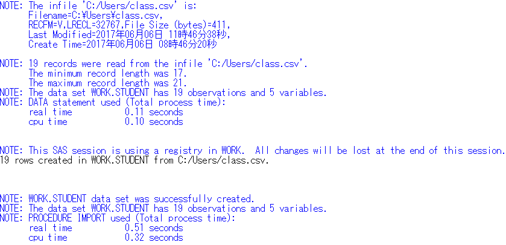

## 1.3 Find basic information about the data set.

The CONTENTS procedure prints information about a SAS data set.

```sas
proc contents data = student;
run;
```

```
                          The CONTENTS Procedure

Data Set Name        WORK.STUDENT                  Observations          19
Member Type          DATA                          Variables             5
Engine               V9                            Indexes               0
Created              07/03/2017 09:17:24           Observation Length    32
Last Modified        07/03/2017 09:17:24           Deleted Observations  0
Protection                                         Compressed            NO
Data Set Type                                      Sorted                NO
Label
Data Representation  WINDOWS_64
Encoding             wlatin1  Western (Windows)


                Alphabetic List of Variables and Attributes

            #    Variable    Type    Len    Format     Informat

            3    Age         Num       8    BEST12.    BEST32.
            4    Height      Num       8    BEST12.    BEST32.
            1    Name        Char      7    $7.        $7.
            2    Sex         Char      1    $1.        $1.
            5    Weight      Num       8    BEST12.    BEST32.
```

## 1.4 Look at the first 5 (last 5) observations.

The PRINT procedure prints a SAS data set, according to the specifications and options provided.

```sas
/* obs= option tells SAS how many observations to print, starting
   with the first observation */
proc print data = student (obs=5);
run;
```

```
   Obs    Name       Sex             Age          Height          Weight

     1    Alfred      M               14              69           112.5
     2    Alice       F               13            56.5              84
     3    Barbara     F               13            65.3              98
     4    Carol       F               14            62.8           102.5
     5    Henry       M               14            63.5           102.5
```

–

```sas
/* print the last 5 observations */
proc print data = student(firstobs=15);
run;
```

```
   Obs    Name       Sex             Age          Height          Weight

    15    Philip      M               16              72             150
    16    Robert      M               12            64.8             128
    17    Ronald      M               15              67             133
    18    Thomas      M               11            57.5              85
    19    William     M               15            66.5             112
```

## 1.5 Calculate means of numeric variables.

The MEANS procedure prints the means of all numeric variables of a SAS data set, as well as other descriptive statistics.

```sas
proc means data = student mean;
run;
```

```
                            The MEANS Procedure

                         Variable            Mean
                         ------------------------
                         Age           13.3157895
                         Height        62.3368421
                         Weight       100.0263158
                         ------------------------
```

## 1.6 Compute summary statistics of the data set.

Summary statistics of a SAS data set are available by running the MEANS procedure and specifying statistics to return.

```sas
/* SAS uses a different method than Python and R to compute
   quartiles, but the method in each language can be changed */
/* maxdec= option tells SAS to print at most 2 numbers behind
   the decimal point */
proc means data = student min q1 median mean q3 max n maxdec=2;
run;
```

```
                            The MEANS Procedure

                                    Lower
 Variable         Minimum        Quartile          Median            Mean
 ------------------------------------------------------------------------
 Age                11.00           12.00           13.00           13.32
 Height             51.30           57.50           62.80           62.34
 Weight             50.50           84.00           99.50          100.03
 ------------------------------------------------------------------------

                                 Upper
              Variable        Quartile         Maximum     N
              ----------------------------------------------
              Age                15.00           16.00    19
              Height             66.50           72.00    19
              Weight            112.50          150.00    19
              ----------------------------------------------
```

## 1.7 Descriptive statistics functions applied to columns of the data set.

```sas
/* The var statement tells SAS which variable to use for the
   procedure */
proc means data = student stddev sum n max min median maxdec=2;
  var Weight;
run;
```

```
                            The MEANS Procedure

                        Analysis Variable : Weight

      Std Dev           Sum   N       Maximum       Minimum        Median
 ------------------------------------------------------------------------
        22.77       1900.50  19        150.00         50.50         99.50
 ------------------------------------------------------------------------
```

## 1.8 Produce a one-way table to describe the frequency of a variable.

The FREQ procedure prints the frequency of categorical or discrete variables of a SAS data set.

### a) Produce a one-way table of a discrete variable.

```sas
proc freq data = student;
  tables Age / nopercent norow nocol;
run;
```

```
                            The FREQ Procedure

                                          Cumulative
                      Age    Frequency     Frequency
                      ------------------------------
                       11           2             2
                       12           5             7
                       13           3            10
                       14           4            14
                       15           4            18
                       16           1            19
```

### b) Produce a one-way table of a categorical variable.

```sas
proc freq data = student;
  tables Sex / nopercent norow nocol;
run;
```

```
                            The FREQ Procedure

                                          Cumulative
                      Sex    Frequency     Frequency
                      ------------------------------
                      F             9             9
                      M            10            19
```

The tables statement allows you to specify multiple variables at once, separated only by a space, so both of these tables could have been created with one FREQ procedure call. The options on the tables statement (nopercent norow nocol) prevent SAS from printing percents in the table, which are printed by default.

## 1.9 Produce a two-way table to visualize the frequency of two categorical (or discrete) variables.

```sas
/* The "*" between two variables on the tables statement
   indicates to produce a two-way table of the two variables */
proc freq data = student;
  tables Age*Sex / nopercent norow nocol;
run;
```

```
                            The FREQ Procedure

                            Table of Age by Sex

                    Age       Sex

                    Frequency|F       |M       |  Total
                    ---------+--------+--------+
                          11 |      1 |      1 |      2
                    ---------+--------+--------+
                          12 |      2 |      3 |      5
                    ---------+--------+--------+
                          13 |      2 |      1 |      3
                    ---------+--------+--------+
                          14 |      2 |      2 |      4
                    ---------+--------+--------+
                          15 |      2 |      2 |      4
                    ---------+--------+--------+
                          16 |      0 |      1 |      1
                    ---------+--------+--------+
                    Total           9       10       19
```

FREQ Procedure

## 1.10 Select a subset of the data that meets a certain criterion.

```sas
data females;
  set student;
  where Sex = "F";
run;
proc print data = females(obs=5);
run;
```

```
   Obs    Name       Sex             Age          Height          Weight

    1     Alice       F               13            56.5              84
    2     Barbara     F               13            65.3              98
    3     Carol       F               14            62.8           102.5
    4     Jane        F               12            59.8            84.5
    5     Janet       F               15            62.5           112.5
```

DATA step: set & where statements

## 1.11 Determine the correlation between two continuous variables.

```sas
/* The nosimple option reduces the output of this procedure */
proc corr data = student pearson nosimple;
var Height Weight;
run;
```

```
                            The CORR Procedure

                     2  Variables:    Height   Weight

                 Pearson Correlation Coefficients, N = 19
                        Prob > |r| under H0: Rho=0

                                  Height        Weight

                    Height       1.00000       0.87779
                                                <.0001

                    Weight       0.87779       1.00000
                                  <.0001
```

CORR Procedure

# 2 Basic Graphing and Plotting Functions

The SGPLOT procedure is a very useful SAS procedure for producing plots from data. For more information on other statements within the SGPLOT procedure, please see the Appendix Section 2.

## 2.1 Visualize a single continuous variable by producing a histogram.

```sas
/* Notice the specifcation of the bins, as well as the xaxis values */
/* SAS denotes "count" as what R & Python denote as "frequency" */
proc sgplot data = student;
  histogram weight / binwidth=20 binstart=40 scale=count;
  xaxis values=(40 to 160 by 20);
run;
```

Output:

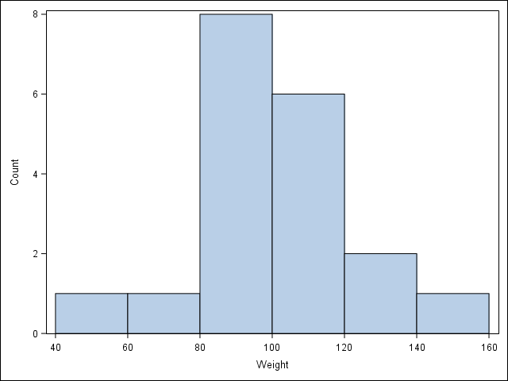

## 2.2 Visualize a single continuous variable by producing a boxplot.

```sas
/* SAS automatically prints the mean on the boxplot */
proc sgplot data = student;
  vbox Weight;
run;
```

Output:

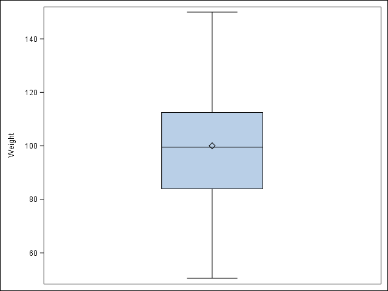

## 2.3 Visualize two continuous variables by producing a scatterplot.

```sas
/* Notice here you specify the y variable followed by the x variable */
proc sgscatter data = student;
  plot Weight * Height;
run;
```

Output:

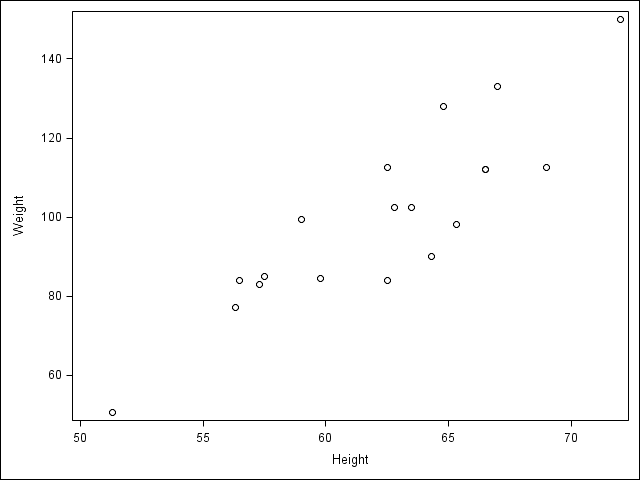

SGSCATTER Procedure

## 2.4 Visualize a relationship between two continuous variables by producing a scatterplot and a plotted line of best fit.

```sas
/* Use proc reg to get the parameter estimates for the line of best fit,
   but don't print the graph (ods graphics off) */
ods graphics off;
proc reg data = student;
  /* Syntax indicates Weight as a function of Height */
  model Weight = Height;
  ods output ParameterEstimates=PE;
run;
ods graphics on;

/* data _null_ indicates to not create a data set, but
   run the code within the data step to create macro
   variables to store the parameter estimates */
data _null_;
  set PE;
  if _n_=1 then call symput('Int', put(estimate, BEST6.));
  else call symput('Slope', put(estimate, BEST6.));
run;

/* Use proc sgplot with the reg statement so it prints the line of best fit,
   and use the inset statement to print the equation of the line
   of best fit */
proc sgplot data = student noautolegend;
  reg y = Weight x = Height;
  inset "Line: Y = &Slope x + &Int" / position=topleft;
run;
```

Output:

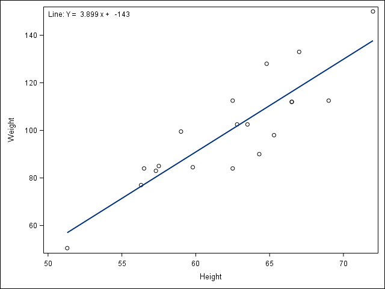

REG Procedure | set statement | [macro variables](https://v8doc.sas.com/sashtml/macro/z1071889.htm) | [call symput()](https://v8doc.sas.com/sashtml/macro/z0210266.htm)

## 2.5 Visualize a categorical variable by producing a bar chart.

```sas
/* Notice here you must first sort by Sex and then plot the vertical
  bar chart */
proc sort data = student;
  by Sex;
run;
proc sgplot data = student;
  vbar Sex;
run;
```

Output:

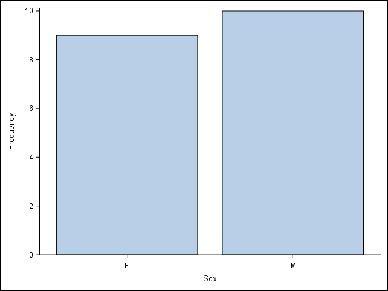

SORT Procedure

## 2.6 Visualize a continuous variable, grouped by a categorical variable, using side-by-side boxplots.

### More advanced side-by-side boxplot with color.

```sas
proc sgplot data = student;
  vbox Weight / group=Sex;
run;
```

Output:

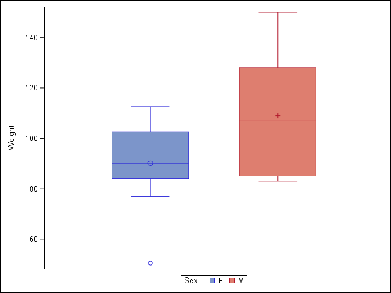

# 3 Basic Data Wrangling and Manipulation

Many of the following examples make use of the SAS DATA step for manipulating and altering data sets, and a main part of the DATA step is the set statement.

## 3.1 Create a new variable in a data set as a function of existing variables in the data set.

```sas
data student;
  set student;
  BMI = Weight / (Height**2) * 703;
run;
proc print data = student(obs=5);
run;
```

```
Obs   Name      Sex            Age         Height         Weight     BMI

  1   Alfred     M              14             69          112.5   16.6115
  2   Alice      F              13           56.5             84   18.4986
  3   Barbara    F              13           65.3             98   16.1568
  4   Carol      F              14           62.8          102.5   18.2709
  5   Henry      M              14           63.5          102.5   17.8703
```

## 3.2 Create a new variable in a data set using if/else logic of existing variables in the data set.

```sas
data student;
  set student;
  if (BMI < 19.0) then BMI_class = "Underweight";
  else BMI_class = "Healthy";
run;
proc print data = student(obs=5);
run;
```

```
Obs Name    Sex          Age       Height       Weight   BMI    BMI_class

  1 Alfred   M            14           69        112.5 16.6115 Underweight
  2 Alice    F            13         56.5           84 18.4986 Underweight
  3 Barbara  F            13         65.3           98 16.1568 Underweight
  4 Carol    F            14         62.8        102.5 18.2709 Underweight
  5 Henry    M            14         63.5        102.5 17.8703 Underweight
```

if-then/else statement

## 3.3 Create a new variable in a data set using mathemtical functions applied to existing variables in the data set.

Using the [log()](http://support.sas.com/documentation/cdl/en/lefunctionsref/63354/HTML/default/viewer.htm#p0urbseuxrkrlyn1tr04y30nt25s.htm), [exp()](http://support.sas.com/documentation/cdl/en/lefunctionsref/63354/HTML/default/viewer.htm#n0ocutx9jgosdln17xg1z75jmkbv.htm), [sqrt()](http://support.sas.com/documentation/cdl/en/lefunctionsref/63354/HTML/default/viewer.htm#n0uc20qbw3wi2jn1y1tan8rq8mnm.htm), & [abs()](http://support.sas.com/documentation/cdl/en/lefunctionsref/63354/HTML/default/viewer.htm#p0xkrj83an7dknn1sgukpmnphcje.htm) functions.

```sas
data student;
  set student;
  LogWeight = log(Weight);
  ExpAge = exp(Age);
  SqrtHeight = sqrt(Height);
  if (BMI < 19.0) then BMI_Neg = -BMI;
  else BMI_Neg = BMI;
  BMI_Pos = abs(BMI_Neg);
  /* Create a Boolean variable, which is handled differently
     in SAS than in Python and R */
  BMI_Check = (BMI_Pos = BMI);
run;
proc print data = student(obs=5);
run;
```

```
Obs Name    Sex          Age       Height       Weight   BMI    BMI_class

  1 Alfred   M            14           69        112.5 16.6115 Underweight
  2 Alice    F            13         56.5           84 18.4986 Underweight
  3 Barbara  F            13         65.3           98 16.1568 Underweight
  4 Carol    F            14         62.8        102.5 18.2709 Underweight
  5 Henry    M            14         63.5        102.5 17.8703 Underweight

      Log                      Sqrt                             BMI_
Obs  Weight      ExpAge       Height     BMI_Neg    BMI_Pos    Check

  1 4.72295    1202604.28    8.30662    -16.6115    16.6115      1
  2 4.43082     442413.39    7.51665    -18.4986    18.4986      1
  3 4.58497     442413.39    8.08084    -16.1568    16.1568      1
  4 4.62986    1202604.28    7.92465    -18.2709    18.2709      1
  5 4.62986    1202604.28    7.96869    -17.8703    17.8703      1
```

if-then/else statement

## 3.4 Drop variables from a data set.

```sas
data student;
  set student (drop = LogWeight ExpAge SqrtHeight BMI_Neg BMI_Pos BMI_Check);
run;
proc print data = student(obs=5);
run;
```

```
Obs Name    Sex          Age       Height       Weight   BMI    BMI_class

  1 Alfred   M            14           69        112.5 16.6115 Underweight
  2 Alice    F            13         56.5           84 18.4986 Underweight
  3 Barbara  F            13         65.3           98 16.1568 Underweight
  4 Carol    F            14         62.8        102.5 18.2709 Underweight
  5 Henry    M            14         63.5        102.5 17.8703 Underweight
```

[drop=](http://support.sas.com/documentation/cdl/en/ledsoptsref/63326/HTML/default/viewer.htm#n15goor3q758g5n1eykstufkpdhy.htm) data set option

## 3.5 Sort a data set by a variable.

### a) Sort data set by a continuous variable.

```sas
proc sort data = student;
  by Age;
run;
proc print data = student(obs=5);
run;
```

```
Obs Name    Sex          Age       Height       Weight   BMI   BMI_class

  1 Joyce    F            11         51.3         50.5 13.4900 Underweight
  2 Thomas   M            11         57.5           85 18.0733 Underweight
  3 James    M            12         57.3           83 17.7715 Underweight
  4 Jane     F            12         59.8         84.5 16.6115 Underweight
  5 John     M            12           59         99.5 20.0944 Healthy
```

### b) Sort data set by a categorical variable.

```sas
proc sort data = student;
  by Sex;
run;
/* Notice that the data is now sorted first by Sex and
   then within Sex by Age */
proc print data = student(obs=5);
run;
```

```
Obs Name    Sex          Age       Height       Weight   BMI    BMI_class

  1 Joyce    F            11         51.3         50.5 13.4900 Underweight
  2 Jane     F            12         59.8         84.5 16.6115 Underweight
  3 Louise   F            12         56.3           77 17.0777 Underweight
  4 Alice    F            13         56.5           84 18.4986 Underweight
  5 Barbara  F            13         65.3           98 16.1568 Underweight
```

SORT Procedure

## 3.6 Compute descriptive statistics of continuous variables, grouped by a categorical variable.

```sas
proc means data = student mean;
  by Sex;
  var Age Height Weight BMI;
run;
```

```
---------------------------------- Sex=F ----------------------------------

                            The MEANS Procedure

                         Variable            Mean
                         ------------------------
                         Age           13.2222222
                         Height        60.5888889
                         Weight        90.1111111
                         BMI           17.0510391
                         ------------------------


---------------------------------- Sex=M ----------------------------------

                         Variable            Mean
                         ------------------------
                         Age           13.4000000
                         Height        63.9100000
                         Weight       108.9500000
                         BMI           18.5942434
                         ------------------------
```

MEANS Procedure

## 3.7 Add a new row to the bottom of a data set.

```sas
/* Look at the tail of the data currently */
proc print data = student(firstobs=15);
run;
```

```
Obs Name    Sex          Age       Height       Weight   BMI   BMI_class

 15 Alfred   M            14           69        112.5 16.6115 Underweight
 16 Henry    M            14         63.5        102.5 17.8703 Underweight
 17 Ronald   M            15           67          133 20.8285 Healthy
 18 William  M            15         66.5          112 17.8045 Underweight
 19 Philip   M            16           72          150 20.3414 Healthy
```

```sas
data student;
  set student end = eof;
  output;
  if eof then do;
    Name = 'Jane';
    Sex = 'F';
    Age = 14;
    Height = 56.3;
    Weight = 77.0;
    BMI = 17.077695;
    BMI_Class = 'Underweight';
    output;
  end;
run;
proc print data = student(firstobs=16);
run;
```

```
Obs Name    Sex          Age       Height       Weight   BMI   BMI_class

 16 Henry    M            14         63.5        102.5 17.8703 Underweight
 17 Ronald   M            15           67          133 20.8285 Healthy
 18 William  M            15         66.5          112 17.8045 Underweight
 19 Philip   M            16           72          150 20.3414 Healthy
 20 Jane     F            14         56.3           77 17.0777 Underweight
```

if-then/else & output statements | do loop, end= & [firstobs=](http://support.sas.com/documentation/cdl/en/ledsoptsref/69751/HTML/default/viewer.htm#p0wjxoxrco6dsgn1ls5n3mbybcng.htm) data set options

## 3.8 Create a user-defined function and apply it to a variable in the data set to create a new variable in the data set.

```sas
proc fcmp outlib=sasuser.userfuncs.myfunc;
  function toKG(lb);
    kg = 0.45359237 * lb;
  return(kg);
endsub;

options cmplib=sasuser.userfuncs;

data studentKG;
  set student;
  Weight_KG = toKG(Weight);
run;

proc print data = studentKG(obs=5);
run;
```

```
   Obs    Name       Sex             Age          Height          Weight

     1    Joyce       F               11            51.3            50.5
     2    Jane        F               12            59.8            84.5
     3    Louise      F               12            56.3              77
     4    Alice       F               13            56.5              84
     5    Barbara     F               13            65.3              98

                                    Weight_
   Obs      BMI       BMI_class        KG

     1    13.4900    Underweight    22.9064
     2    16.6115    Underweight    38.3286
     3    17.0777    Underweight    34.9266
     4    18.4986    Underweight    38.1018
     5    16.1568    Underweight    44.4521
```

FCMP Procedure

# 4 More Advanced Data Wrangling

## 4.1 Drop observations with missing information.

```sas
/* Notice the use of the fish data set because it has some missing
   observations */
proc import out = fish
  datafile='C:/Users/fish.csv'
  dbms = csv replace;
  getnames = yes;
run;

/* First sort by Weight, requesting those with NA for Weight first,
   which SAS does automatically */
proc sort data = fish;
  by Weight;
run;
proc print data = fish(obs=5);
run;
```

```
      Obs    Species          Weight         Length1         Length2

        1     Bream                .            29.5              32
        2     Roach                0              19            20.5
        3     Perch              5.9             7.5             8.4
        4     Smelt              6.7             9.3             9.8
        5     Smelt                7            10.1            10.6

      Obs         Length3          Height           Width

        1            37.3         13.9129          5.0728
        2            22.8          6.4752          3.3516
        3             8.8           2.112           1.408
        4            10.8          1.7388          1.0476
        5            11.6          1.7284          1.1484
```

```sas
data new_fish;
  set fish;
  /* Notice the not-equal operator (^=) and how SAS denotes
     missing values (.) */
  if (Weight ^= .);
run;
proc print data = new_fish(obs=5);
run;
```

```
      Obs    Species          Weight         Length1         Length2

        1     Roach                0              19            20.5
        2     Perch              5.9             7.5             8.4
        3     Smelt              6.7             9.3             9.8
        4     Smelt                7            10.1            10.6
        5     Smelt              7.5              10            10.5

      Obs         Length3          Height           Width

        1            22.8          6.4752          3.3516
        2             8.8           2.112           1.408
        3            10.8          1.7388          1.0476
        4            11.6          1.7284          1.1484
        5            11.6           1.972            1.16
```

SORT Procedure | if-then/else statement

## 4.2 Merge two data sets together on a common variable.

### a) First, select specific columns of a data set to create two smaller data sets.

```sas
/* Notice the use of the student data set again, however we want to reload it
   without the changes we've made previously  */
proc import out = student
  datafile = 'C:/Users/class.csv'
  dbms = csv replace;
  getnames = yes;
run;
data student1;
  set student(keep= Name Sex Age);
run;
proc print data = student1(obs=5);
run;
```

```
                   Obs    Name       Sex             Age

                     1    Alfred      M               14
                     2    Alice       F               13
                     3    Barbara     F               13
                     4    Carol       F               14
                     5    Henry       M               14
```

```sas
data student2;
  set student(keep= Name Height Weight);
run;
proc print data = student2(obs=5);
run;
```

```
              Obs    Name             Height          Weight

                1    Alfred               69           112.5
                2    Alice              56.5              84
                3    Barbara            65.3              98
                4    Carol              62.8           102.5
                5    Henry              63.5           102.5
```

[keep=](http://support.sas.com/documentation/cdl/en/ledsoptsref/69751/HTML/default/viewer.htm#p0vw9lyyxk1cxkn0zzfemrsr3t9a.htm) data set option

### b) Second, we want to merge the two smaller data sets on the common variable.

```sas
data new;
  merge student1 student2;
  by Name;
run;
proc print data = new(obs=5);
run;
```

```
   Obs    Name       Sex             Age          Height          Weight

     1    Alfred      M               14              69           112.5
     2    Alice       F               13            56.5              84
     3    Barbara     F               13            65.3              98
     4    Carol       F               14            62.8           102.5
     5    Henry       M               14            63.5           102.5
```

DATA step: merge statement

### c) Finally, we want to check to see if the merged data set is the same as the original data set.

```sas
proc compare base = student compare = new brief;
run;
```

```
                           The COMPARE Procedure
                 Comparison of WORK.STUDENT with WORK.NEW
                              (Method=EXACT)

NOTE: No unequal values were found. All values compared are exactly equal.
```

COMPARE Procedure

## 4.3 Merge two data sets together by index number only.

### a) First, select specific columns of a data set to create two smaller data sets.

```sas
data newstudent1;
  set student(keep= Name Sex Age);
run;
proc print data = newstudent1(obs=5);
run;
```

```
                   Obs    Name       Sex             Age

                     1    Alfred      M               14
                     2    Alice       F               13
                     3    Barbara     F               13
                     4    Carol       F               14
                     5    Henry       M               14
```

```sas
data newstudent2;
  set student(keep= Height Weight);
run;
proc print data = newstudent2(obs=5);
run;
```

```
                    Obs          Height          Weight

                      1              69           112.5
                      2            56.5              84
                      3            65.3              98
                      4            62.8           102.5
                      5            63.5           102.5
```

[keep=](http://support.sas.com/documentation/cdl/en/ledsoptsref/69751/HTML/default/viewer.htm#p0vw9lyyxk1cxkn0zzfemrsr3t9a.htm) data set option

### b) Second, we want to join the two smaller data sets.

```sas
data new2;
  merge newstudent1 newstudent2;
run;
proc print data = new2(obs=5);
run;
```

```
   Obs    Name       Sex             Age          Height          Weight

     1    Alfred      M               14              69           112.5
     2    Alice       F               13            56.5              84
     3    Barbara     F               13            65.3              98
     4    Carol       F               14            62.8           102.5
     5    Henry       M               14            63.5           102.5
```

merge statement

### c) Finally, we want to check to see if the joined data set is the same as the original data set.

```sas
proc compare base = student compare = new2 brief;
run;
```

```
                           The COMPARE Procedure
                 Comparison of WORK.STUDENT with WORK.NEW2
                              (Method=EXACT)

NOTE: No unequal values were found. All values compared are exactly equal.
```

COMPARE Procedure

## 4.4 Create a pivot table to summarize information about a data set.

```sas
/* Notice we are using a new data set that needs to be read into the
   environment */
proc import out = price
  datafile = 'C:/Users/price.csv'
  dbms = csv replace;
  getnames = yes;
run;

/* The following code is used to remove the "," and "$" characters from the
   ACTUAL column so that values can be summed */
data price;
  set price;
  num_actual = input(actual, dollar10.);
run;

proc sql;
  create table categorysales as
    select country, state, prodtype,
    product, sum(num_actual) as REVENUE
    from price
  group by country, state, prodtype, product;
quit;
proc print data = categorysales(obs=5);
run;
```

```
     Obs    COUNTRY    STATE         PRODTYPE     PRODUCT     REVENUE

       1    Canada     British Co    FURNITURE     BED       197706.6
       2    Canada     British Co    FURNITURE     SOFA      216282.6
       3    Canada     British Co    OFFICE        CHAI      200905.2
       4    Canada     British Co    OFFICE        DESK      186262.2
       5    Canada     Ontario       FURNITURE     BED       194493.6
```

[input()](http://support.sas.com/documentation/cdl/en/lrdict/64316/HTML/default/viewer.htm#a000180357.htm) function | SQL Procedure

## 4.5 Return all unique values from a text variable.

```sas
proc iml;
  use price;
    read all var {STATE};
  close price;

  unique_states = unique(STATE);
  print(unique_states);
quit;
```

```
                              unique_states
       COL1       COL2       COL3       COL4       COL5       COL6

  ROW1 Baja Calif British Co California Campeche   Colorado   Florida

                              unique_states
       COL7       COL8       COL9       COL10      COL11      COL12

  ROW1 Illinois   Michoacan  New York   North Caro Nuevo Leon Ontario

                              unique_states
                  COL13      COL14      COL15      COL16

             ROW1 Quebec     Saskatchew Texas      Washington
```

IML Procedure | [unique()](http://support.sas.com/documentation/cdl/en/imlug/67502/HTML/default/viewer.htm#imlug_langref_sect482.htm) function

# 5 Preparation & Basic Regression

## 5.1 Pre-process a data set using principal component analysis.

```sas
/* Notice we are using a new data set that needs to be read into the
   environment */
proc import out = iris
  datafile = 'C:/Users/iris.csv'
  dbms = csv replace;
  getnames = yes;
run;

data features;
  set iris(drop=Target);
run;

proc princomp data = features noprint outstat = feat_princomp;
  var SepalLength SepalWidth PetalLength PetalWidth;
run;

data eigenvectors;
    set feat_princomp;
    where _TYPE_ = "SCORE";
run;
proc print data = eigenvectors;
run;
```

```
                               Sepal       Sepal      Petal       Petal
  Obs    _TYPE_    _NAME_     Length       Width      Length      Width

   1     SCORE     Prin1      0.52237    -0.26335    0.58125     0.56561
   2     SCORE     Prin2      0.37232     0.92556    0.02109     0.06542
   3     SCORE     Prin3     -0.72102     0.24203    0.14089     0.63380
   4     SCORE     Prin4     -0.26200     0.12413    0.80115    -0.52355
```

[drop=](http://support.sas.com/documentation/cdl/en/ledsoptsref/63326/HTML/default/viewer.htm#n15goor3q758g5n1eykstufkpdhy.htm) data set option | PRINCOMP Procedure

## 5.2 Split data into training and testing data and export as a .csv file.

```sas
/* outall option tells SAS to add a flag showing which observations were
   chosen */
/* seed = 29 specifies the seed for random values so the results are
   reproducible */
proc surveyselect data = iris outall out = all method = srs samprate = 0.7
                              seed = 29;
run;

data train (drop = selected) test (drop = selected);
    set all;
    if (selected = 1) then output train;
  else output test;
run;

proc export data = train
   outfile = 'C:\Users\iris_train.csv'
   dbms = csv;
run;
proc export data = test
   outfile = 'C:\Users\iris_test.csv'
   dbms = csv;
run;
```

SURVEYSELECT Procedure | [drop=](http://support.sas.com/documentation/cdl/en/ledsoptsref/63326/HTML/default/viewer.htm#n15goor3q758g5n1eykstufkpdhy.htm) data set option | EXPORT Procedure

## 5.3 Fit a logistic regression model.

```sas
/* Notice we are using a new data set that needs to be read into the
   environment */
proc import out = tips
  datafile = 'C:/Users/tips.csv'
  dbms = csv replace;
  getnames = yes;
run;

/* The following code is used to determine if the individual left more than
   a 15% tip */
data tips;
  set tips;
  if (tip > 0.15*total_bill) then greater15 = 1;
  else greater15 = 0;
run;

/* The descending option tells SAS to model the probability that
  greater15 = 1 */
proc genmod data=tips descending;
  model greater15 = total_bill / dist = bin link = logit lrci;
run;
```

```
                           The GENMOD Procedure

                             Model Information

                      Data Set              WORK.TIPS
                      Distribution           Binomial
                      Link Function             Logit
                      Dependent Variable    greater15

                  Number of Observations Read         244
                  Number of Observations Used         244
                  Number of Events                    135
                  Number of Trials                    244

                             Response Profile

                     Ordered                     Total
                       Value    greater15    Frequency

                           1    1                  135
                           2    0                  109

PROC GENMOD is modeling the probability that greater15='1'.

                  Criteria For Assessing Goodness Of Fit

     Criterion                     DF           Value        Value/DF

     Log Likelihood                         -156.8714
     Full Log Likelihood                    -156.8714
     AIC (smaller is better)                 317.7428
     AICC (smaller is better)                317.7926
     BIC (smaller is better)                 324.7371


Algorithm converged.

            Analysis Of Maximum Likelihood Parameter Estimates

                                           Likelihood Ratio
                              Standard      95% Confidence           Wald
 Parameter    DF   Estimate      Error          Limits         Chi-Square

 Intercept     1     1.6477     0.3547     0.9722     2.3667        21.58
 total_bill    1    -0.0725     0.0168    -0.1069    -0.0408        18.65
 Scale         0     1.0000     0.0000     1.0000     1.0000

                            Analysis Of Maximum
                           Likelihood Parameter
                                 Estimates

                          Parameter    Pr > ChiSq

                          Intercept        <.0001
                          total_bill       <.0001
                          Scale

NOTE: The scale parameter was held fixed.
```

if-then/else statement | GENMOD Procedure

## 5.4 Fit a linear regression model.

```sas
/* Fit a linear regression model of tip by total_bill */
proc reg data = tips outest=RegOut;
    tip_hat: model tip = total_bill;
quit;
```

```
                             The REG Procedure
                              Model: tip_hat
                         Dependent Variable: tip

                  Number of Observations Read         244
                  Number of Observations Used         244

                           Analysis of Variance

                                   Sum of          Mean
 Source                  DF       Squares        Square   F Value   Pr > F

 Model                    1     212.42373     212.42373    203.36   <.0001
 Error                  242     252.78874       1.04458
 Corrected Total        243     465.21248

           Root MSE              1.02205    R-Square     0.4566
           Dependent Mean        2.99828    Adj R-Sq     0.4544
           Coeff Var            34.08782

                            Parameter Estimates

                         Parameter       Standard
   Variable      DF       Estimate          Error    t Value    Pr > |t|

   Intercept      1        0.92027        0.15973       5.76      <.0001
   total_bill     1        0.10502        0.00736      14.26      <.0001
```

REG Procedure

# 6 Supervised Machine Learning

## 6.1 Fit a logistic regression model on training data and assess against testing data.

### a) Fit a logistic regression model on training data.

```sas
/* Notice we are using new data sets that need to be read into the
   environment */
proc import out = train
  datafile = 'C:/Users/tips_train.csv'
  dbms = csv replace;
  getnames = yes;
run;
proc import out = test
  datafile = 'C:/Users/tips_test.csv'
  dbms = csv replace;
  getnames = yes;
run;

/* The following code is used to determine if the individual left more than
   a 15% tip */
data train;
  set train;
  if (tip > 0.15*total_bill) then greater15 = 1;
  else greater15 = 0;
run;
data test;
  set test;
  if (tip > 0.15*total_bill) then greater15 = 1;
  else greater15 = 0;
run;

/* The descending option tells SAS to model the probability that
  greater15 = 1 */
proc genmod data=train descending;
  model greater15 = total_bill / dist = bin link = logit lrci;
  store out = logmod;
run;
```

```
                           The GENMOD Procedure

                            Model Information

                     Data Set              WORK.TRAIN
                     Distribution            Binomial
                     Link Function              Logit
                     Dependent Variable     greater15

                  Number of Observations Read         195
                  Number of Observations Used         195
                  Number of Events                    109
                  Number of Trials                    195

                             Response Profile

                     Ordered                     Total
                       Value    greater15    Frequency

                           1    1                  109
                           2    0                   86

PROC GENMOD is modeling the probability that greater15='1'.

                  Criteria For Assessing Goodness Of Fit

     Criterion                     DF           Value        Value/DF

     Log Likelihood                         -125.2918
     Full Log Likelihood                    -125.2918
     AIC (smaller is better)                 254.5836
     AICC (smaller is better)                254.6461
     BIC (smaller is better)                 261.1296


Algorithm converged.

            Analysis Of Maximum Likelihood Parameter Estimates

                                           Likelihood Ratio
                              Standard      95% Confidence           Wald
 Parameter    DF   Estimate      Error          Limits         Chi-Square

 Intercept     1     1.6461     0.3946     0.8973     2.4501        17.40
 total_bill    1    -0.0706     0.0185    -0.1088    -0.0359        14.59
 Scale         0     1.0000     0.0000     1.0000     1.0000

                            Analysis Of Maximum
                           Likelihood Parameter
                                 Estimates

                          Parameter    Pr > ChiSq

                          Intercept        <.0001
                          total_bill       0.0001
                          Scale

NOTE: The scale parameter was held fixed.
```

### b) Assess the model against the testing data.

```sas
/* Prediction on testing data */
proc plm source = logmod noprint;
    score data = test out = preds pred = pred / ilink;
run;

/* Determine how many were correctly classified */
data preds;
    set preds;
    if (pred < 0.5) then label = 0;
    else label = 1;
    if (label = greater15) then Result = "Correct";
    else Result = "Wrong";
run;

proc freq data = preds;
tables Result / nopercent norow nocol;
run;
```

```
                            The FREQ Procedure

                                            Cumulative
                    Result     Frequency     Frequency
                    ----------------------------------
                    Correct          34            34
                    Wrong            15            49
```

## 6.2 Fit a linear regression model on training data and assess against testing data.

### a) Fit a linear regression model on training data.

```sas
/* Notice we are using new data sets that need to be read into the
  environment */
proc import out = train
  datafile = 'C:/Users/boston_train.csv'
  dbms = csv replace;
  getnames = yes;
run;
proc import out = test
  datafile = 'C:/Users/boston_test.csv'
  dbms = csv replace;
  getnames = yes;
run;

proc reg data = train outest=RegOut;
  predY: model Target = _0-_12;
quit;
```

```
                             The REG Procedure
                               Model: predY
                        Dependent Variable: Target

                  Number of Observations Read         354
                  Number of Observations Used         354

                           Analysis of Variance

                                   Sum of          Mean
 Source                  DF       Squares        Square   F Value   Pr > F

 Model                   13         22145    1703.47137     68.48   <.0001
 Error                  340    8458.20364      24.87707
 Corrected Total        353         30603

           Root MSE              4.98769    R-Square     0.7236
           Dependent Mean       22.48249    Adj R-Sq     0.7131
           Coeff Var            22.18479

                           Parameter Estimates

                        Parameter       Standard
   Variable     DF       Estimate          Error    t Value    Pr > |t|

   Intercept     1       36.10820        6.50497       5.55      <.0001
   _0            1       -0.08563        0.04277      -2.00      0.0461
   _1            1        0.04603        0.01715       2.68      0.0076
   _2            1        0.03641        0.07601       0.48      0.6322
   _3            1        3.24796        1.07414       3.02      0.0027
   _4            1      -14.87294        4.63609      -3.21      0.0015
   _5            1        3.57687        0.53699       6.66      <.0001
   _6            1       -0.00870        0.01685      -0.52      0.6059
   _7            1       -1.36890        0.25296      -5.41      <.0001
   _8            1        0.31312        0.08237       3.80      0.0002
   _9            1       -0.01288        0.00460      -2.80      0.0054
   _10           1       -0.97690        0.17100      -5.71      <.0001
   _11           1        0.01133        0.00336       3.37      0.0008
   _12           1       -0.52672        0.06256      -8.42      <.0001
```

### b) Assess the model against the testing data.

```sas
/* Predicton on testing data */
proc score data = test score=RegOut type=parms predict out = Pred;
    var _0-_12;
run;

/* Compute the squared differences between predicted and target */
data Pred;
    set Pred;
    sq_error = (predY - Target)**2;
run;

/* Compute the mean of the squared differences (mean squared error) as an
   assessment of the model */
proc means data = Pred mean;
  var sq_error;
run;
```

```
                            The MEANS Procedure

                       Analysis Variable : sq_error

                                       Mean
                               ------------
                                 17.7713080
                               ------------
```

REG Procedure | SCORE Procedure | MEANS Procedure

## 6.3 Fit a decision tree model on training data and assess against testing data.

### a) Fit a decision tree classification model.

#### i) Fit a decision tree classification model on training data and determine variable importance

```sas
/* Notice we are using new data sets that need to be read into the
   environment */
proc import out = train
    datafile = 'C:/Users/breastcancer_train.csv'
    dbms = csv replace;
    getnames = yes;
run;
proc import out = test
    datafile = 'C:/Users/breastcancer_test.csv'
    dbms = csv replace;
    getnames = yes;
run;

/* HPSPLIT procedure is used to fit a decision tree model */
proc hpsplit data = train seed = 29;
    target Target;
    input _0-_29;
    /* Export information about variable importance */
    output importance=import;
    /* Export the model code so this can be used to score testing data */
    code file='hpbreastcancer.sas';
run;

/* Output of this model gives assessment against training data
     and variable importance */
```

```
                           The HPSPLIT Procedure

                          Performance Information

                    Execution Mode       Single-Machine
                    Number of Threads    4

                         Data Access Information

                Data          Engine    Role     Path

                WORK.TRAIN    V9        Input    On Client

                             Model Information

          Split Criterion Used                            Entropy
          Pruning Method                          Cost-Complexity
          Subtree Evaluation Criterion            Cost-Complexity
          Number of Branches                                    2
          Maximum Tree Depth Requested                         10
          Maximum Tree Depth Achieved                           6
          Tree Depth                                            3
          Number of Leaves Before Pruning                      15
          Number of Leaves After Pruning                        6
          Model Event Level                                     1

            Number of Observations Read                    398
            Number of Observations Used                    398



                           The HPSPLIT Procedure

                       Model-Based Confusion Matrix

                                 Predicted           Error
                Actual            1            0      Rate

                1               242            1    0.0041
                0                10          145    0.0645
```

[output cut: 8 more lines]

```
               Model-Based Fit Statistics for Selected Tree

                                     AUC

                                  0.9852

                            Variable Importance

                                  Training
               Variable    Relative    Importance      Count

               _23           1.0000       11.2865          1
               _27           0.4072        4.5962          1
               _1            0.3487        3.9356          2
               _6            0.2355        2.6581          1
```

#### ii. Assess the model against the testing data.

```sas
/* Score the test data using the model code */
data scored;
    set test;
    %include 'hpbreastcancer.sas';
run;

/* Use prediction probabilities to generate predictions, and compare these
     to the true responses */
/* If the prediction probability is less than 0.5, classify this as a 0
   and otherwise classify as a 1.  This isn't the best method -- a better
   method would be randomly assigning a 0 or 1 when a probability of 0.5
   occurrs, but this insures that results are consistent */
data scored;
    set scored;
    if (P_Target1 < 0.5) then prediction = 0;
    else prediction = 1;
    if (Target = prediction) then Result = "Correct";
  else Result = "Wrong";
run;

/* Determine how many were correctly classified */
proc freq data = scored;
  tables Result / nopercent norow nocol;
run;
```

```
                            The FREQ Procedure

                                            Cumulative
                    Result     Frequency     Frequency
                    ----------------------------------
                    Correct         157           157
                    Wrong            14           171
```

HPSPLIT Procedure | %include & if-then/else statements | FREQ Procedure

### b) Fit a decision tree regression model.

#### i) Fit a decision tree regression model on training data and determine variable importance.

```sas
proc import out = train
    datafile = 'C:/Users/boston_train.csv'
    dbms = csv replace;
    getnames = yes;
run;
proc import out = test
    datafile = 'C:/Users/boston_test.csv'
    dbms = csv replace;
    getnames = yes;
run;

/* HPSPLIT procedure is used to fit a decision tree model */
proc hpsplit data = train seed = 29;
    target Target / level = int;
    input _0-_12;
    /* Export information about variable importance */
    output importance=import;
    /* Export the model code so this can be used to score testing data */
    code file='hpboston.sas';
run;

/* Output of this model gives assessment against training data
   and variable importance */
```

```
                           The HPSPLIT Procedure

                          Performance Information

                    Execution Mode       Single-Machine
                    Number of Threads    4

                         Data Access Information

                Data          Engine    Role     Path

                WORK.TRAIN    V9        Input    On Client

                             Model Information

          Split Criterion Used                           Variance
          Pruning Method                          Cost-Complexity
          Subtree Evaluation Criterion            Cost-Complexity
          Number of Branches                                    2
          Maximum Tree Depth Requested                         10
          Maximum Tree Depth Achieved                          10
          Tree Depth                                           10
          Number of Leaves Before Pruning                     188
          Number of Leaves After Pruning                      101

            Number of Observations Read                    354
            Number of Observations Used                    354



                           The HPSPLIT Procedure

                Model-Based Fit Statistics for Selected Tree

                          N
                     Leaves           ASE           RSS

                        101        0.9750         345.2

                            Variable Importance

                                  Training
               Variable    Relative    Importance      Count

               _5            1.0000         132.8         13
               _12           0.6026       79.9998         16
               _7            0.3968       52.6772          9
               _4            0.2663       35.3541         12
               _0            0.2324       30.8579          7
               _9            0.1574       20.8933          8
               _6            0.1202       15.9544         12
               _10           0.1063       14.1112          4
               _11           0.0855       11.3541          8
               _2            0.0713        9.4695          5
               _8            0.0696        9.2408          3
               _1            0.0583        7.7437          3
```

#### ii. Assess the model against the testing data.

```sas
/* Score the test data using the model code */
data scored;
    set test;
    %include 'hpboston.sas';
run;

/* Compute the squared differences between predicted and target */
data scored;
    set scored;
    sq_error = (P_Target - Target)**2;
run;

/* Compute the mean of the squared differences (mean squared error) as an
     assessment of the model */
proc means data = scored mean;
  var sq_error;
run;
```

```
                            The MEANS Procedure

                       Analysis Variable : sq_error

                                       Mean
                               ------------
                                 24.6222895
                               ------------
```

HPSPLIT Procedure | %include statement | MEANS Procedure

## 6.4 Fit a random forest model on training data and assess against testing data.

### a) Fit a random forest classification model.

#### i) Fit a random forest classification model on training data and determine variable importance.

```sas
proc import out = train
    datafile = 'C:/Users/breastcancer_train.csv'
    dbms = csv replace;
    getnames = yes;
run;
proc import out = test
    datafile = 'C:/Users/breastcancer_test.csv'
    dbms = csv replace;
    getnames = yes;
run;

/* Output includes information about variable importance */
proc hpforest data = train;
    input _0 - _29 / level = interval;
    target Target / level = nominal;
    save file = 'hpbreastcancer2.bin';
run;
```

```
                          The HPFOREST Procedure

                          Performance Information

                    Execution Mode       Single-Machine
                    Number of Threads    4

                         Data Access Information

                Data          Engine    Role     Path

                WORK.TRAIN    V9        Input    On Client

                            Model Information

         Parameter                          Value

         Variables to Try                       5    (Default)
         Maximum Trees                        100    (Default)
         Inbag Fraction                       0.6    (Default)
         Prune Fraction                         0    (Default)
         Prune Threshold                      0.1    (Default)
         Leaf Fraction                    0.00001    (Default)
         Leaf Size Setting                      1    (Default)
         Leaf Size Used                         1
         Category Bins                         30    (Default)
         Interval Bins                        100
         Minimum Category Size                  5    (Default)
         Node Size                         100000    (Default)
         Maximum Depth                         20    (Default)
         Alpha                                  1    (Default)
         Exhaustive                          5000    (Default)
         Rows of Sequence to Skip               5    (Default)
         Split Criterion                        .    Gini
         Preselection Method                    .    BinnedSearch
         Missing Value Handling                 .    Valid value

                          Number of Observations

                Type                                      N
```

[output cut: 247 more lines]

```
   _5                12    0.001882    -0.00010    0.003764     0.00152
   _16               17    0.001134    -0.00055    0.002268     0.00089
   _11               23    0.001679    -0.00057    0.003358     0.00096
   _8                22    0.001543    -0.00077    0.003086     0.00052
   _18               22    0.001787    -0.00105    0.003573     0.00081
   _9                23    0.001656    -0.00105    0.003312     0.00063
   _4                22    0.002237    -0.00114    0.004475     0.00147
   _1                58    0.008366    -0.00147    0.016732     0.00648
   _24               80    0.010527    -0.00149    0.021054     0.00906
   _25               55    0.005040    -0.00151    0.010081     0.00449
   _28               70    0.008423    -0.00168    0.016846     0.00617
   _15               16    0.001345    -0.00203    0.002690    -0.00059
   _14               29    0.001679    -0.00282    0.003357    -0.00110
   _19               49    0.003804    -0.00413    0.007609    -0.00028
   _29               74    0.005801    -0.00418    0.011603     0.00225
```

#### ii) Assess the model against the testing data.

```sas
/* Prediction on testing data */
ods select none;
proc hp4score data = test seed = 29;
    score file = 'hpbreastcancer2.bin' out = scored;
run;
ods select all;

/* Determine how many were correctly classified */
data scored;
    set scored;
    if (I_Target = Target) then Result = "Correct";
    else Result = "Wrong";
run;

proc freq data = scored;
  tables Result / nopercent norow nocol;
run;
```

```
                            The FREQ Procedure

                                            Cumulative
                    Result     Frequency     Frequency
                    ----------------------------------
                    Correct         166           166
                    Wrong             5           171
```

HPFOREST Procedure | HP4SCORE Procedure | FREQ Procedure

### b) Fit a random forest regression model.

#### i) Fit a random forest regression model on training data and determine variable importance.

```sas
proc import out = train
    datafile = 'C:/Users/boston_train.csv'
    dbms = csv replace;
    getnames = yes;
run;
proc import out = test
    datafile = 'C:/Users/boston_test.csv'
    dbms = csv replace;
    getnames = yes;
run;

proc hpforest data = train;
    input _0-_12 / level = interval;
    target Target / level = interval;
    save file = 'hpboston2.bin';
run;
```

```
                          The HPFOREST Procedure

                          Performance Information

                    Execution Mode       Single-Machine
                    Number of Threads    4

                         Data Access Information

                Data          Engine    Role     Path

                WORK.TRAIN    V9        Input    On Client

                            Model Information

         Parameter                          Value

         Variables to Try                       4    (Default)
         Maximum Trees                        100    (Default)
         Inbag Fraction                       0.6    (Default)
         Prune Fraction                         0    (Default)
         Prune Threshold                      0.1    (Default)
         Leaf Fraction                    0.00001    (Default)
         Leaf Size Setting                      1    (Default)
         Leaf Size Used                         1
         Category Bins                         30    (Default)
         Interval Bins                        100
         Minimum Category Size                  5    (Default)
         Node Size                         100000    (Default)
         Maximum Depth                         20    (Default)
         Alpha                                  1    (Default)
         Exhaustive                          5000    (Default)
         Rows of Sequence to Skip               5    (Default)
         Split Criterion                        .    Variance
         Preselection Method                    .    BinnedSearch
         Missing Value Handling                 .    Valid value

                          Number of Observations

                Type                                      N
```

[output cut: 121 more lines]

```
  Variable   of Rules        MSE        MSE          Error          Error

  _12            4396   27.04197   22.13960       1.817229       1.145998
  _5             1613   25.99545   20.99293       1.680908       1.237562
  _2              898    7.75271    3.96375       0.506857       0.217635
  _10            1018    4.16985    2.55019       0.303633       0.122254
  _4             1056    4.76512    2.18816       0.433949       0.194056
  _9             1350    3.15479    1.05221       0.309260       0.069817
  _0              379    1.75671    0.26459       0.150208       0.043154
  _3              212    0.59890   -0.01786       0.037628      -0.003165
  _7             2295    6.34926   -0.02228       0.597998       0.117993
  _1              152    0.13857   -0.15254       0.024181      -0.008075
  _8              783    0.53835   -0.24442       0.090505      -0.027870
  _6             1528    1.72691   -0.31032       0.265848       0.000333
  _11            3429    2.83003   -0.60993       0.457235      -0.011947
```

#### ii) Assess the model against the testing data.

```sas
/* Prediction on testing data */
ods select none;
proc hp4score data = test seed = 29;
    score file = 'hpboston2.bin' out = scored;
run;
ods select all;

/* Compute the squared differences between predicted and target */
data scored;
    set scored;
    sq_error = (P_Target - Target)**2;
run;

/* Compute the mean of the squared differences (mean squared error) as an
   assessment of the model */
proc means data = scored mean;
  var sq_error;
run;
```

```
                            The MEANS Procedure

                       Analysis Variable : sq_error

                                       Mean
                               ------------
                                  8.9447360
                               ------------
```

HPFOREST Procedure | HP4SCORE Procedure | MEANS Procedure

## 6.5 Fit a gradient boosting model on training data and assess against testing data.

### a) Fit a gradient boosting classification model.

Currently, there is not a gradient boosting procedure available in Base SAS Therefore, the best method to create a gradient boosting model as of now is using SAS Enterprise Miner. Create the following diagram in SAS Enterprise Miner:

Diagram:

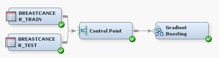

For the Gradient Boosting node, set Seed = 29, set Shrinkage = 0.01, and set Train Proportion = 100.

This diagram results in the following variable importance and misclassification against training & testing data:

Output:

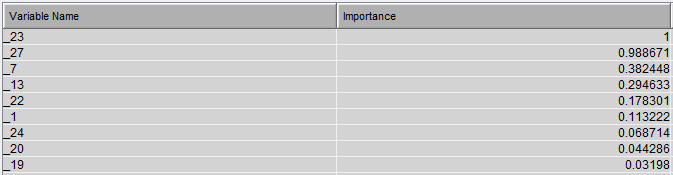

Output:

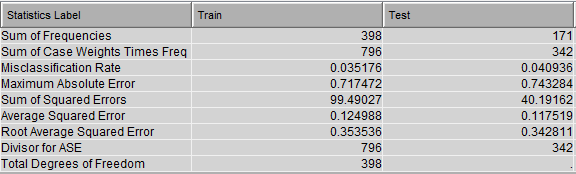

Output:

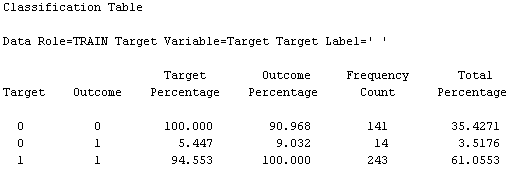

[Gradient Boosting node](http://support.sas.com/documentation/cdl/en/emgsj/66018/HTML/default/viewer.htm#p03iy98sk0c9bvn1r6x7ppx8uj08.htm)

### b) Fit a gradient boosting regression model.

Again, there is not a gradient boosting procedure available in Base SAS, currently. Create the following diagram in SAS Enterprise Miner:

Diagram:

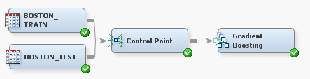

For the Gradient Boosting node, set Seed = 29, set Shrinkage = 0.01, and set Train Proportion = 100.

This diagram results in the following variable importance and root mean squared error against training & testing data:

Output:

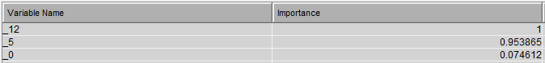

Output:

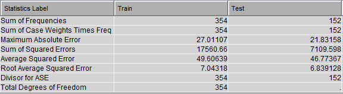

[Gradient Boosting node](http://support.sas.com/documentation/cdl/en/emgsj/66018/HTML/default/viewer.htm#p03iy98sk0c9bvn1r6x7ppx8uj08.htm)

## 6.6 Fit an extreme gradient boosting model on taining data and assess against testing data.

### a) Fit an extreme gradient boosting classification model.

#### Fit an extreme gradient boosting classification model on training data and assess the model against the testing data.

For more information on the R code used below, please see the R Tutorial.

```sas
proc iml;
  submit / R;
    train = read.csv('C:/Users/breastcancer_train.csv')
    test = read.csv('C:/Users/breastcancer_test.csv')

    library(xgboost)
      set.seed(29)

    xgbMod <- xgboost(data.matrix(subset(train, select = -c(Target))),
                      data.matrix(train$Target), max_depth = 3, nrounds = 2,
                      objective = "binary:logistic", n_estimators = 2500,
                      shrinkage = .01)
    # Prediction on testing data
    predictions <- predict(xgbMod, data.matrix(subset(test, select =
                                                      -c(Target))))
    pred.response <- ifelse(predictions < 0.5, 0, 1)

    # Determine how many were correctly classified
    Results <- ifelse(test$Target == pred.response, "Correct", "Wrong")
    table(Results)
  endsubmit;
quit;
```

```
Results
Correct   Wrong
    165       6
```

#### Fit an extreme gradient boosting regression model on training data and assess the model against the testing data.

```sas
proc iml;
  submit / R;
    train = read.csv('C:/Users/boston_train.csv')
    test = read.csv('C:/Users/boston_test.csv')

    library(xgboost)
      set.seed(29)

    xgbMod <- xgboost(data.matrix(subset(train, select = -c(Target))),
                      data.matrix(train$Target / 50), max_depth = 3,
                      nrounds = 2, n_estimators = 2500, shrinkage = .01)

    # Predict the target in the testing data, remembering to
    # multiply by 50
    prediction = data.frame(matrix(ncol = 0, nrow = nrow(test)))
    prediction$target_hat <- predict(xgbMod,
                                     data.matrix(subset(test,
                                                 select = - c(Target))))*50

    # Compute the squared difference between predicted tip and actual tip
    prediction$sq_diff <- (prediction$target_hat - test$Target)**2

    # Compute the mean of the squared differences (mean squared error)
    # as an assessment of the model
    mean_sq_error <- mean(prediction$sq_diff)
    print(mean_sq_error)
  endsubmit;
quit;
```

```
[1] 36.13079
```

IML Procedure

## 6.7 Fit a support vector model on training data and assess against testing data.

### a) Fit a support vector classification model.

#### i) Fit a support vector classification model on training data.

```sas
proc import out = train
    datafile = 'C:/Users/breastcancer_train.csv'
    dbms = csv replace;
    getnames = yes;
run;
proc import out = test
    datafile = 'C:/Users/breastcancer_test.csv'
    dbms = csv replace;
    getnames = yes;
run;

/* Fit a support vector classification model */
proc hpsvm data = train;
  input _0-_29 / level = interval;
    target Target / level = nominal;
    code file='hpbreastcancer3.sas';
run;
```

```
                            The HPSVM Procedure

                          Performance Information

                    Execution Mode       Single-Machine
                    Number of Threads    4

                         Data Access Information

                Data          Engine    Role     Path

                WORK.TRAIN    V9        Input    On Client

                            Model Information

                 Task Type                 C_CLAS
                 Optimization Technique    Interior Point
                 Scale                     YES
                 Kernel Function           Linear
                 Penalty Method            C
                 Penalty Parameter         1
                 Maximum Iterations        25
                 Tolerance                 1e-06

                Number of Observations Read             398
                Number of Observations Used             398

                             Training Results

             Inner Product of Weights               35.2508001
             Bias                                    -6.375275
             Total Slack (Constraint Violations)    34.3511008
             Norm of Longest Vector                 3.79226578
             Number of Support Vectors                      71
             Number of Support Vectors on Margin            63
             Maximum F                              11.4630802
             Minimum F                              -4.7061491
             Number of Effects                              30
             Columns in Data Matrix                         30

```

[output cut: 22 more lines]

```
                                  Training Prediction
               Observed           1           0       Total

               1                243           0         243
               0                  7         148         155
               Total            250         148         398

                              Fit Statistics

                          Statistic      Training

                          Accuracy         0.9824
                          Error            0.0176
                          Sensitivity      1.0000
                          Specificity      0.9548
```

HPSVM Procedure

#### ii) Assess the model against the testing data.

```sas
/* Prediction on testing data */
data scored;
    set test;
    %include 'hpbreastcancer3.sas';
run;

/* Determine how many were correctly classified */
data scored;
    set scored;
    if (I_Target = Target) then Result = "Correct";
    else Result = "Wrong";
run;

proc freq data = scored;
  tables Result / nopercent norow nocol;
run;
```

```
                            The FREQ Procedure

                                            Cumulative
                    Result     Frequency     Frequency
                    ----------------------------------
                    Correct         167           167
                    Wrong             4           171
```

%include & if-then/else statements | FREQ Procedure

### b) Fit a support vector regression model.

Not available in this current release.

## 6.8 Fit a neural network model on training data and assess against testing data.

### a) Fit a neural network classification model.

#### i) Fit a neural network classification model on training data.

```sas
/* Notice we are using new data sets */
proc import out = train
  datafile = 'C:/Users/digits_train.csv'
  dbms = csv replace;
  getnames = yes;
run;
proc import out = test
  datafile = 'C:/Users/digits_test.csv'
  dbms = csv replace;
  getnames = yes;
run;

/* In order to use the NEURAL Procedure we first need to create a data
   mining database (DMDB) that reflects the original data */
proc dmdb batch data = train
    out = dmtrain
    dmdbcat = digits;
  var _0 - _63;
  class Target;
  target Target;
run;
proc dmdb batch data = test
    out = dmtest
    dmdbcat = digits;
  var _0 - _63;
  class Target;
  target Target;
run;

/* Now we can fit the neural network model */
/* Neural network produces a lot of output which is why here
   "nloptions noprint" is specified */
proc neural data = train dmdbcat = digits random = 29;
  nloptions noprint;
  input _0 - _63 / level = interval;
  target Target / level = nominal;
  archi MLP hidden=100;
  train maxiter = 200;
  score out = out outfit = fit;
  score data = test out = gridout;
run;
```

DMDB Procedure | NEURAL Procedure

#### ii) Assess the model against the testing data.

```sas
/* Prediction on testing data */
data scored;
    set gridout;
    rename I_Target = Prediction;
run;

/* This produces a confusion matrix */
proc freq data = scored;
    tables Target*Prediction / nopercent norow nocol;
run;
```

```
                            The FREQ Procedure

                       Table of Target by Prediction

      Target     Prediction(Into: Target)

      Frequency|0       |1       |2       |3       |4       |  Total
      ---------+--------+--------+--------+--------+--------+
             0 |     58 |      0 |      0 |      0 |      0 |     58
      ---------+--------+--------+--------+--------+--------+
             1 |      1 |     56 |      0 |      0 |      0 |     58
      ---------+--------+--------+--------+--------+--------+
             2 |      0 |      0 |     58 |      0 |      0 |     58
      ---------+--------+--------+--------+--------+--------+
             3 |      0 |      0 |      0 |     58 |      0 |     59
      ---------+--------+--------+--------+--------+--------+
             4 |      0 |      0 |      0 |      0 |     51 |     54
      ---------+--------+--------+--------+--------+--------+
             5 |      0 |      0 |      0 |      0 |      0 |     59
      ---------+--------+--------+--------+--------+--------+
             6 |      0 |      0 |      0 |      0 |      0 |     41
      ---------+--------+--------+--------+--------+--------+
             7 |      0 |      0 |      0 |      0 |      0 |     51
      ---------+--------+--------+--------+--------+--------+
             8 |      0 |      4 |      0 |      0 |      0 |     45
      ---------+--------+--------+--------+--------+--------+
             9 |      0 |      0 |      0 |      0 |      0 |     57
      ---------+--------+--------+--------+--------+--------+
      Total          59       60       58       58       51      540
      (Continued)

                       Table of Target by Prediction

      Target     Prediction(Into: Target)

      Frequency|5       |6       |7       |8       |9       |  Total
      ---------+--------+--------+--------+--------+--------+
             0 |      0 |      0 |      0 |      0 |      0 |     58
      ---------+--------+--------+--------+--------+--------+
             1 |      0 |      1 |      0 |      0 |      0 |     58
      ---------+--------+--------+--------+--------+--------+
             2 |      0 |      0 |      0 |      0 |      0 |     58
      ---------+--------+--------+--------+--------+--------+
             3 |      1 |      0 |      0 |      0 |      0 |     59
      ---------+--------+--------+--------+--------+--------+
             4 |      1 |      1 |      0 |      1 |      0 |     54
      ---------+--------+--------+--------+--------+--------+
             5 |     58 |      0 |      0 |      0 |      1 |     59
      ---------+--------+--------+--------+--------+--------+
             6 |      0 |     41 |      0 |      0 |      0 |     41
      ---------+--------+--------+--------+--------+--------+
             7 |      1 |      0 |     50 |      0 |      0 |     51
      ---------+--------+--------+--------+--------+--------+
             8 |      0 |      0 |      0 |     39 |      2 |     45
      ---------+--------+--------+--------+--------+--------+
             9 |      2 |      0 |      0 |      2 |     53 |     57
      ---------+--------+--------+--------+--------+--------+
      Total          63       43       50       42       56      540
```

FREQ Procedure

### b) Fit a neural network regression model.

#### i) Fit a neural network regression model on training data.

```sas
proc import out = train
  datafile = 'C:/Users/boston_train.csv'
  dbms = csv replace;
  getnames = yes;
run;
proc import out = test
  datafile = 'C:/Users/boston_test.csv'
  dbms = csv replace;
  getnames = yes;
run;

/* In order to use the NEURAL Procedure we first need to create a data
   mining database (DMDB) that reflects the original data */
proc dmdb batch data = train
    out = dmtrain
    dmdbcat = boston;
  var _0 - _12 Target;
  target Target;
run;
proc dmdb batch data = test
    out = dmtest
    dmdbcat = boston;
  var _0 - _12 Target;
  target Target;
run;

/* Now we can fit the neural network model */
/* Neural network produces a lot of output which is why here
   "nloptions noprint" is specified */
proc neural data = train dmdbcat = boston random = 29;
  nloptions noprint;
  archi MLP hidden=100;
  input _0 - _12 / level = interval;
  target Target / level = interval;
  train maxiter = 250;
  score data = test outfit = netfit out = gridout;
run;
```

DMDB Procedure | NEURAL Procedure

#### ii) Assess the model against the testing data.

```sas
/* Prediction on testing data */
data scored(keep = sq_error P_Target Target);
    set gridout;
    sq_error = (P_Target - Target)**2;
run;

/* Determine mean squared error */
proc means data = scored mean;
var sq_error;
run;
```

```
                            The MEANS Procedure

                       Analysis Variable : sq_error

                                       Mean
                               ------------
                                 16.1149499
                               ------------
```

MEANS Procedure

# 7 Unsupervised Machine Learning

## 7.1 KMeans Clustering

```sas
proc import out = iris
    datafile = 'C:/Users/iris.csv'
    dbms = csv replace;
    getnames = yes;
run;

data iris;
    length Species $ 20;
    set iris;
    if (Target = 0) then Species = "Setosa";
    if (Target = 1) then Species = "Versicolor";
    if (Target = 2) then Species = "Virginica";
run;

proc fastclus data=iris maxclusters=3 out=kmeans random = 29 noprint;
    var PetalLength PetalWidth SepalLength SepalWidth;
run;

proc freq data = kmeans;
    tables Species*Cluster / nopercent nocol norow;
run;
```

```
                            The FREQ Procedure

                        Table of Species by CLUSTER

              Species     CLUSTER(Cluster)

              Frequency  |       1|       2|       3|  Total
              -----------+--------+--------+--------+
              Setosa     |      0 |     50 |      0 |     50
              -----------+--------+--------+--------+
              Versicolor |      0 |      0 |     50 |     50
              -----------+--------+--------+--------+
              Virginica  |     33 |      0 |     17 |     50
              -----------+--------+--------+--------+
              Total            33       50       67      150
```

FASTCLUS Procedure | FREQ Procedure

## 7.2 Spectral Clustering

For more information on the R code used below, please see the R Tutorial.

```sas
proc iml;
  submit / R;
    iris = read.csv('C:/Users/iris.csv')
      iris$Species = ifelse(iris$Target == 0, "Setosa",
                            ifelse(iris$Target == 1, "Versicolor",
                                   "Virginica"))
      features <- as.matrix(subset(iris, select = c(PetalLength,
                                                    PetalWidth, SepalLength,
                                                    SepalWidth)))
    library(kernlab)
    set.seed(29)
    spectral <- specc(features, centers = 3, iterations = 10,
                      nystrom.red = TRUE)
    labels <- as.data.frame(spectral)
    table(iris$Species, labels$spectral)
  endsubmit;
quit;
```

```
              1  2  3
  Setosa     50  0  0
  Versicolor  0 47  3
  Virginica   0  3 47
```

IML Procedure

## 7.3 Ward Hierarchical Clustering

```sas
proc import out = iris
  datafile = 'C:/Users/iris.csv'
  dbms = csv replace;
  getnames = yes;
run;

data iris;
  length Species $ 20;
  set iris;
    if (Target = 0) then Species = "Setosa";
    if (Target = 1) then Species = "Versicolor";
    if (Target = 2) then Species = "Virginica";
run;

proc cluster data = iris method = ward print=15 ccc pseudo noprint;
   var petal: sepal:;
   copy species;
run;

proc tree noprint ncl=3 out=out;
   copy petal: sepal: species;
run;

proc freq data = out;
  tables Species*Cluster / nopercent norow nocol;
run;
```

Output:

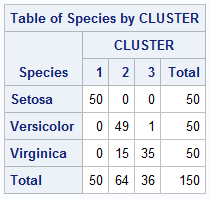

CLUSTER Procedure | TREE Procedure | FREQ Procedure

## 7.4 DBSCAN

For more information on the R code used below, please see the R Tutorial.

```sas
proc iml;
  submit / R;
    iris = read.csv('C:/Users/iris.csv')
      iris$Species = ifelse(iris$Target == 0, "Setosa",
                            ifelse(iris$Target == 1, "Versicolor",
                                   "Virginica"))
      features <- as.matrix(subset(iris, select = c(PetalLength,
                                                    PetalWidth, SepalLength,
                                                    SepalWidth)))
    library(dbscan)
      set.seed(29)
    dbscan <- dbscan(features, eps = 0.5)
    labels <- dbscan$cluster
    table(iris$Species, labels)
  endsubmit;
quit;
```

```
            labels
              0  1  2
  Setosa      1 49  0
  Versicolor  6  0 44
  Virginica  10  0 40
```

IML Procedure

## 7.5 Self-organizing map

Currently, there is not a self-organizing map procedure available in Base SAS. Therefore, the best method to create a self-organizing map as of now is using SAS Enterprise Miner. First, you need to read in the Iris data set, setting the Species/Target variable to be dropped before investigation.

Setup:

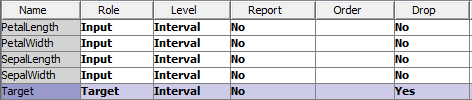

Then create the following diagram in SAS Enterprise Miner:

Diagram:

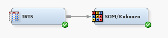

For the SOM/Kohonen node set the following options:

1. Choose the Kohonen SOM method.
2. Set row and column to both be 4.
3. Under the “Kohonen” options section, set “Use Defaults” to “No”, and open the Kohonen Options window by clicking the … box.
4. Set the following options in the popup window:

Options:

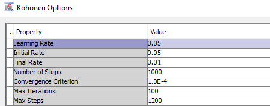

This model produces the following output which is similar to the output of R and Python:

Output:

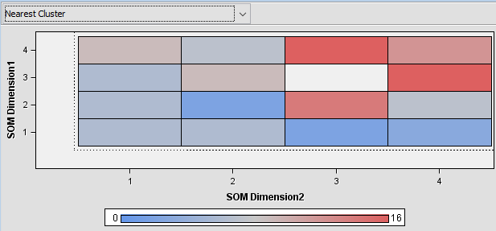

# 8 Forecasting

## 8.1 Fit an ARIMA model to a timeseries.

### a) Plot the timeseries.

```sas
/* Read in new data set */
proc import out = air
  datafile = 'C:/Users/air.csv'
  dbms = csv replace;
  getnames = yes;
run;

proc timeseries data = air plot = series;
    id date interval = month;
    var air;
run;
```

Output:

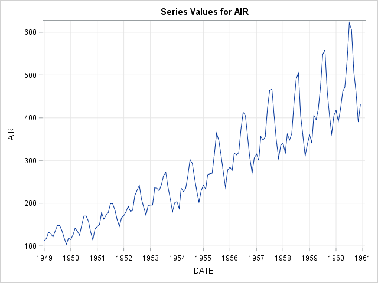

TIMESERIES Procedure

### b) Fit an ARIMA model and predict 2 years (24 months).

The output of this code has been limited for space reasons.

```sas
proc arima data = air;
    identify var = air(1,12) noprint;
    estimate q=(1)(12) noint method=ml noprint;
    forecast id=date interval=month out=forecast;
run;

/* SAS automatically predicts 2 years out and plots the predictions */
```

Output:

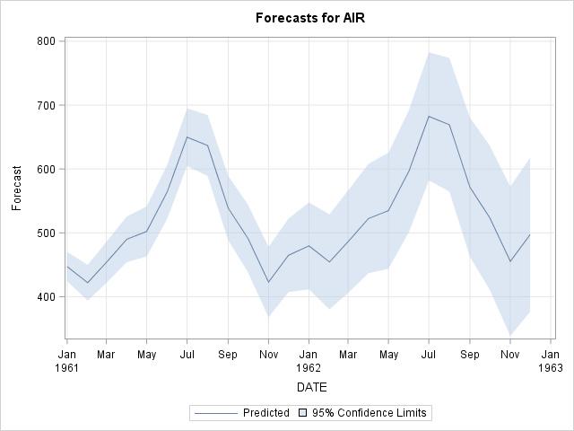

ARIMA Procedure

## 8.2 Fit a Simple Exponential Smoothing model to a timeseries.

### a) Plot the timeseries.

```sas
proc import out = usecon
  datafile = 'C:/Users/usecon.csv'
  dbms = csv replace;
  getnames = yes;
run;
proc timeseries data = usecon plot = series;
    id date interval = month;
    var petrol;
run;
```

```
                         The TIMESERIES Procedure

                              Input Data Set

                  Name                        WORK.USECON
                  Label
                  Time ID Variable                   DATE
                  Time Interval                     MONTH
                  Length of Seasonal Cycle             12
```

Output:

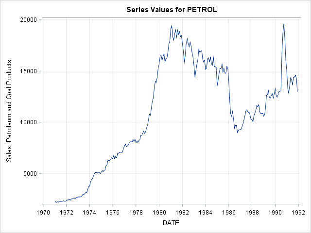

TIMESERIES Procedure

### b) Fit a Simple Exponential Smoothing model, predict 2 years (24 months) out and plot predictions.

```sas
proc esm data = usecon out = forecast lead = 24 plot = forecasts;
    id date interval = month;
    forecast petrol / model = simple;
run;
```

```
                             The ESM Procedure

                              Input Data Set

                  Name                        WORK.USECON
                  Label
                  Time ID Variable                   DATE
                  Time Interval                     MONTH
                  Length of Seasonal Cycle             12
                  Forecast Horizon                     24

                           Variable Information

                  Name                            PETROL
                  Label
                  First                          JAN1971
                  Last                           DEC1991
                  Number of Observations Read        252
```

Output:

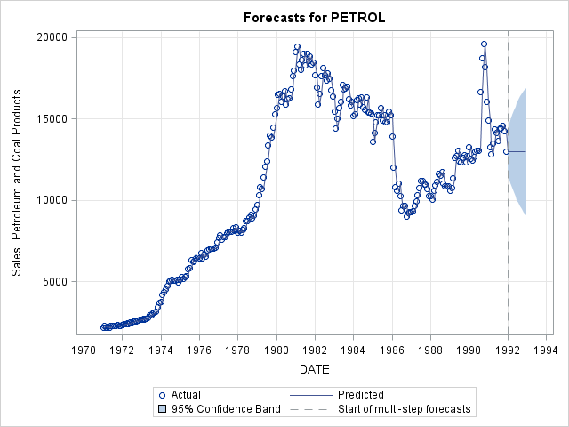

ESM Procedure

## 8.3 Fit a Holt-Winters model to a timeseries.

### a) Plot the timeseries.

```sas
proc timeseries data = usecon plot = series;
    id date interval = month;
    var vehicles;
run;
```

```
                         The TIMESERIES Procedure

                              Input Data Set

                  Name                        WORK.USECON
                  Label
                  Time ID Variable                   DATE
                  Time Interval                     MONTH
                  Length of Seasonal Cycle             12
```

Output:

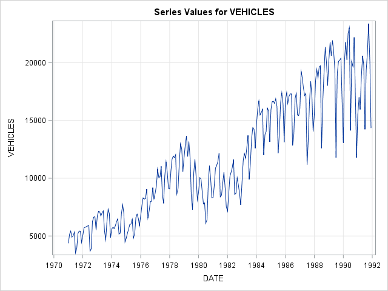

TIMESERIES Procedure

### b) Fit a Holt-Winters additive model, predict 2 years (24 months) out and plot predictions.

```sas
proc esm data = usecon out = forecast lead = 24 plot = forecasts;
    id date interval = month;
    forecast vehicles / model = addwinters;
run;
```

Output:

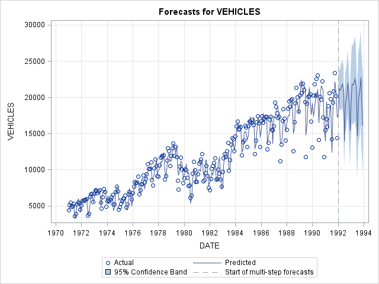

ESM Procedure

# 9 Model Evaluation & Selection

## 9.1 Evaluate the accuracy of regression models.

### a) Evaluation on training data.

```sas
proc import out = train
  datafile = 'C:/Users/boston_train.csv'
  dbms = csv replace;
  getnames = yes;
run;
proc import out = test
  datafile = 'C:/Users/boston_test.csv'
  dbms = csv replace;
  getnames = yes;
run;

/* Random Forest Regression Model */
ods select none;
proc hpforest data = train ;
    input _0-_12 / level = interval;
    target Target / level = interval;
    save file = 'rfMod.bin';
run;
ods select all;

/* Evaluation on training data  */
ods select none;
proc hp4score data = train;
    score file = 'rfMod.bin' out = scored_train;
run;
ods select all;

/* Determine coefficient of determination score */
proc iml;
  use scored_train;
    read all var _ALL_ into data;
  close scored_train;
  tip = data[,1];
  pred_rf = data[,2];
  r2_rf = 1 - ( (sum((tip - pred_rf)##2)) / (sum((tip - mean(tip))##2)) );
  print(r2_rf);
quit;
```

```
                                   r2_rf

                                 0.9751729
```

### b) Evaluation on testing data.

```sas
/* Random Forest Regression Model (rfMod) */

/* Evaluation on testing data  */
ods select none;
proc hp4score data = test;
    score file = 'rfMod.bin' out = scored_test;
run;
ods select all;

/* Determine coefficient of determination score */
proc iml;
  use scored_test;
    read all var _ALL_ into data;
  close scored_test;
  tip = data[,1];
  pred_rf = data[,2];
  r2_rf = 1 - ( (sum((tip - pred_rf)##2)) / (sum((tip - mean(tip))##2)) );
  print(r2_rf);
quit;
```

```
                                   r2_rf

                                 0.8882254
```

The formula used here for the coefficient score is based off the Python skearn formula for [r2_score](http://scikit-learn.org/stable/modules/model_evaluation.html#r2-score-the-coefficient-of-determination).

HPFOREST Procedure | HP4SCORE Procedure | IML Procedure

## 9.2 Evaluate the accuracy of classification models.

### a) Evaluation on training data.

```sas
proc import out = train
    datafile = 'C:/Users/digits_train.csv'
    dbms = csv replace;
    getnames = yes;
run;
proc import out = test
    datafile = 'C:/Users/digits_test.csv'
    dbms = csv replace;
    getnames = yes;
run;

/* Random Forest Classification Model */
ods select none;
proc hpforest data = train;
    input _0-_63 / level = interval;
    target Target / level = nominal;
    save file = 'rfMod.bin';
run;

/* Evaluation on training data */
proc hp4score data = train;
    score file = 'rfMod.bin' out = scored;
run;
ods select all;

data scored(keep = Target I_Target correct);
    set scored;
    correct = (I_Target = Target);
run;

/* Determine accuracy score */
proc iml;
    use scored;
      read all var _ALL_ into data;
    close scored;

    accuracy_forest = (1/nrow(data)) * sum(data[,2]);

    print(accuracy_forest);
quit;
```

```
                              accuracy_forest

                                            1
```

### b) Evaluation on testing data.

```sas
/* Random Forest Classification Model (rfMod) */

/* Evaluation on testing data */
ods select none;
proc hp4score data = test;
    score file = 'rfMod.bin' out = scored;
run;
ods select all;

data scored(keep = Target I_Target correct);
    set scored;
    correct = (I_Target = Target);
run;

/* Determine accuracy score */
proc iml;
    use scored;
      read all var _ALL_ into data;
    close scored;

    accuracy_forest = (1/nrow(data)) * sum(data[,2]);

    print(accuracy_forest);
quit;
```

```
                              accuracy_forest

                                    0.9740741
```

The formula used here for the accuracy score is based off the Python skearn formula for [accuracy_score](http://scikit-learn.org/stable/modules/model_evaluation.html#accuracy-score).

HPFOREST Procedure | HP4SCORE Procedure | IML Procedure

## 9.3 Evaluation with cross validation.

### a) KFold

The HPFOREST output for the 5 models has been removed from the output in this tutorial for the sake of space.

```sas
proc import out = breastcancer
    datafile = 'C:/Users/breastcancer.csv'
    dbms = csv replace;
    getnames = yes;
run;

data folds;
    set breastcancer;
    *randomly assign observation to one of K groups;
    call streaminit(29);
    rand=ceil(5*rand('UNIFORM'));
    output;
run;

%macro hp_KFolds();

data train1 test1 train2 test2 train3 test3
     train4 test4 train5 test5;
    set folds;
    %do i = 1 %to 5;
        %do j = 1 %to 5;
            if (rand = &j) then do;
                if (&i ^= &j) then output train&i;
                else output test&i;
            end;
        %end;
    %end;
    drop rand;
run;

%do i = 1 %to 5;

ods select none;
proc hpforest data = train&i;
    input _0-_29 / level = interval;
    target Target / level = nominal;
    save file = 'hpbreastcancer&i.bin';
run;

proc hp4score data = test&i;
    score file = 'hpbreastcancer&i.bin' out = scored_&i;
run;
ods select all;

data scored_&i;
    set scored_&i;
    correct = (I_Target = Target);
run;

proc freq data = scored_&i noprint;
  tables correct / out=FreqCount&i;
run;

%end;

%mend;

%hp_KFolds()

data FreqCount;
    set FreqCount1 FreqCount2 FreqCount3 FreqCount4 FreqCount5;
    if (correct = 1);
run;

proc means data = FreqCount mean std;
  var PERCENT;
run;
```

```
                            The MEANS Procedure

          Analysis Variable : PERCENT Percent of Total Frequency

                               Mean         Std Dev
                       ----------------------------
                         96.0918078       1.8699234
                       ----------------------------
```

HPFOREST Procedure | HP4SCORE Procedure | FREQ Procedure | MEANS Procedure

### b) ShuffleSplit

The HPFOREST output for the 5 models has been removed from the output in this tutorial for the sake of space.

```sas
proc import out = breastcancer
    datafile = 'C:/Users/breastcancer.csv'
    dbms = csv replace;
    getnames = yes;
run;

proc surveyselect data = breastcancer out = cv seed = 29 samprate = 0.7
                                        outall reps = 5;
run;

data train1 train2 train3 train4 train5 test1 test2 test3 test4 test5;
     set cv;
     if (replicate = 1) then do;
        if (selected = 1) then output train1;
        else output test1;
   end;
   if (replicate = 2) then do;
        if (selected = 1) then output train2;
        else output test2;
   end;
   if (replicate = 3) then do;
        if (selected = 1) then output train3;
        else output test3;
     end;
   if (replicate = 4) then do;
        if (selected = 1) then output train4;
        else output test4;
   end;
   if (replicate = 5) then do;
        if (selected = 1) then output train5;
        else output test5;
     end;
run;

%macro hp_replicate();

%do i = 1 %to 5;

ods select none;
proc hpforest data = train&i;
    input _0-_29 / level = interval;
    target Target / level = nominal;
    save file = 'hpbreastcancer&i.bin';
run;

proc hp4score data = test&i;
    score file = 'hpbreastcancer&i.bin' out = scored_&i;
run;
ods select all;

data scored_&i;
    set scored_&i;
    correct = (I_Target = Target);
run;

proc freq data = scored_&i noprint;
  tables correct / out=FreqCount&i;
run;

%end;

%mend;

%hp_replicate()

data FreqCount;
    set FreqCount1 FreqCount2 FreqCount3 FreqCount4 FreqCount5;
    if (correct = 1);
run;

proc means data = FreqCount mean std;
  var PERCENT;
run;
```

```
                        The SURVEYSELECT Procedure

                Selection Method    Simple Random Sampling

                   Input Data Set           BREASTCANCER
                   Random Number Seed                 29
                   Sampling Rate                     0.7
                   Sample Size                       399
                   Selection Probability         0.70123
                   Sampling Weight                     0
                   Number of Replicates                5
                   Total Sample Size                1995
                   Output Data Set                    CV



                            The MEANS Procedure

          Analysis Variable : PERCENT Percent of Total Frequency

                               Mean         Std Dev
                       ----------------------------
                         95.7647059       0.6443795
                       ----------------------------
```

SURVEYSELECT Procedure | HPFOREST Procedure | HP4SCORE Procedure | FREQ Procedure | MEANS Procedure

# 10 Text Analytics

# 11 Deep Learning

# Appendix

## 1 Built-in SAS Data Types

- [CHAR](http://support.sas.com/documentation/cdl/en/fedsqlref/67364/HTML/default/viewer.htm#n19bf2z7e9p646n0z224cokuj567.htm) The SAS implementation of a string as a fixed-length character string of length *n*.
- [DOUBLE](http://support.sas.com/documentation/cdl/en/fedsqlref/67364/HTML/default/viewer.htm#n19bf2z7e9p646n0z224cokuj567.htm) A decimal point number implemented as a 64-bit double precision, floating-point number.

## 2 SAS Procedures

#### [ARIMA](https://support.sas.com/documentation/onlinedoc/ets/132/arima.pdf)

#### [CLUSTER](https://support.sas.com/documentation/cdl/en/statug/63033/HTML/default/viewer.htm#statug_cluster_sect001.htm)

#### [COMPARE](http://support.sas.com/documentation/cdl/en/proc/65145/HTML/default/viewer.htm#p1l5iwaf47ma83n1euxxp10g8xh5.htm)

#### [CONTENTS](http://support.sas.com/documentation/cdl/en/proc/65145/HTML/default/viewer.htm#n1hqa4dk5tay0an15nrys1iwr5o2.htm)

#### [CORR](http://support.sas.com/documentation/cdl/en/procstat/66703/HTML/default/viewer.htm#procstat_corr_overview.htm)

#### [DMDB](https://support.sas.com/documentation/onlinedoc/miner/em43/dmdb.pdf)

#### [FCMP](http://support.sas.com/documentation/cdl/en/proc/65145/HTML/default/viewer.htm#n1aozmc89vjkpzn1q6a54nleh56o.htm)

#### [ESM](https://support.sas.com/documentation/onlinedoc/ets/132/esm.pdf)

#### [EXPORT](http://support.sas.com/documentation/cdl/en/proc/70377/HTML/default/viewer.htm#p09k160vk93xxhn171zz1z6551w2.htm)

#### [FASTCLUS](https://support.sas.com/documentation/cdl/en/statug/63033/HTML/default/viewer.htm#statug_fastclus_sect001.htm)

#### [FREQ](https://support.sas.com/documentation/cdl/en/statug/63962/HTML/default/viewer.htm#statug_freq_sect001.htm)

#### [GENMOD](https://support.sas.com/documentation/cdl/en/statuggenmod/61787/PDF/default/statuggenmod.pdf)

#### [HP4SCORE](https://support.sas.com/documentation/onlinedoc/miner/em14/emhpprcref.pdf)

#### [HPFOREST](https://support.sas.com/documentation/onlinedoc/miner/em14/emhpprcref.pdf)

#### [HPSPLIT](http://support.sas.com/documentation/cdl/en/stathpug/66410/HTML/default/viewer.htm#stathpug_hpsplit_overview.htm)

#### [HPSVM](http://documentation.sas.com/?docsetId=emhpprcref&docsetVersion=14.2&docsetTarget=emhpprcref_hpsvm_overview.htm&locale=en)

#### [IML](https://support.sas.com/documentation/cdl/en/imlug/63541/PDF/default/imlug.pdf)

#### [IMPORT](http://support.sas.com/documentation/cdl/en/acpcref/69731/HTML/default/viewer.htm#p0mqdq52ktqgjjn1vseqoiuyt3v1.htm)

#### [MEANS](http://support.sas.com/documentation/cdl/en/proc/65145/HTML/default/viewer.htm#p0f0fjpjeuco4gn1ri963f683mi4.htm)

#### [NEURAL](http://support.sas.com/documentation/onlinedoc/miner/em43/neural.pdf)

#### [PRINCOMP](https://support.sas.com/documentation/cdl/en/statug/63347/HTML/default/viewer.htm#princomp_toc.htm)

#### [PRINT](http://support.sas.com/documentation/cdl/en/proc/65145/HTML/default/viewer.htm#p10qiuo2yicr4qn17rav8kptnjpu.htm)

#### [PLM](https://support.sas.com/documentation/cdl/en/statug/63347/HTML/default/viewer.htm#statug_plm_a0000000115.htm)

#### [REG](https://support.sas.com/documentation/cdl/en/statug/63033/HTML/default/viewer.htm#statug_reg_sect001.htm)

#### [SCORE](https://support.sas.com/documentation/cdl/en/statug/63347/HTML/default/viewer.htm#statug_score_sect001.htm)

#### [SGPLOT](http://support.sas.com/documentation/cdl/en/grstatproc/69716/HTML/default/viewer.htm#p1t32i8511t1gfn17sw07yxtazad.htm)

- [histogram](http://support.sas.com/documentation/cdl/en/grstatproc/69716/HTML/default/viewer.htm#n17xrpcduau1f8n1c1nhe477pv18.htm)
- [inset](http://support.sas.com/documentation/cdl/en/grstatproc/69716/HTML/default/viewer.htm#p0hz27ehuzdd6pn0zaic6x52pkav.htm)
- [reg](http://support.sas.com/documentation/cdl/en/grstatproc/69716/HTML/default/viewer.htm#p0mn6vl6clqbgyn1ivs69lezdxhf.htm)
- [scatter](http://support.sas.com/documentation/cdl/en/grstatproc/69716/HTML/default/viewer.htm#p1lcbd3lhs3t3bn1jk6d8sjt2yqx.htm)
- [vbox](http://support.sas.com/documentation/cdl/en/grstatproc/69716/HTML/default/viewer.htm#n1waawwbez01ppn15dn9ehmxzihf.htm)

#### [SGSCATTER](http://support.sas.com/documentation/cdl/en/grstatproc/62603/HTML/default/viewer.htm#sgscatter-syn.htm)

#### [SORT](http://support.sas.com/documentation/cdl/en/proc/70377/HTML/default/viewer.htm#p0ha9ymifyaqldn14m2xlqw252wa.htm)

#### [SQL](https://support.sas.com/documentation/cdl/en/sqlproc/69822/HTML/default/viewer.htm#n1oihmdy7om5rmn1aorxui3kxizl.htm)

#### [SURVEYSELECT](https://support.sas.com/documentation/cdl/en/statug/63347/HTML/default/viewer.htm#statug_surveyselect_sect001.htm)

#### [TIMESERIES](http://support.sas.com/documentation/cdl/en/etsug/66840/HTML/default/viewer.htm#etsug_timeseries_overview.htm)

#### [TREE](https://support.sas.com/documentation/cdl/en/statug/63033/HTML/default/viewer.htm#statug_tree_sect001.htm)

## 3 [SAS DATA step](http://support.sas.com/documentation/cdl/en/basess/68381/HTML/default/viewer.htm#n053a58fwk57v7n14h8x7y7u34y4.htm)

Statements:

#### [%include](http://support.sas.com/documentation/cdl/en/lrdict/64316/HTML/default/viewer.htm#a000214504.htm)

#### [if-then/else](http://support.sas.com/documentation/cdl/en/lrdict/64316/HTML/default/viewer.htm#a000202239.htm)

#### [infile](http://support.sas.com/documentation/cdl/en/lrdict/64316/HTML/default/viewer.htm#a000146932.htm)

#### [input](http://support.sas.com/documentation/cdl/en/lrdict/64316/HTML/default/viewer.htm#a000146292.htm)

#### [merge](http://support.sas.com/documentation/cdl/en/lrdict/64316/HTML/default/viewer.htm#a000202970.htm)

#### [output](http://support.sas.com/documentation/cdl/en/lrdict/64316/HTML/default/viewer.htm#a000194540.htm)

#### [set](http://support.sas.com/documentation/cdl/en/lrdict/64316/HTML/default/viewer.htm#a000173782.htm)

#### [where](http://support.sas.com/documentation/cdl/en/lrdict/64316/HTML/default/viewer.htm#a000202951.htm)

# Alphabetical Index

## [Data Frame](http://support.sas.com/documentation/cdl/en/lrcon/62955/HTML/default/viewer.htm#a001005709.htm)

A two-dimensional tabular structure with labeled axes (rows and columns), where data observations are represented by rows and data variables are represented by columns.

## [Dictionary](https://www.google.com/url?q=http://support.sas.com/resources/papers/proceedings12/147-2012.pdf&ust=1496196720000000&usg=AFQjCNGcqLlU2Ur5Qv_62TM4zJEQY6LjTA&hl=en-US)

An associative array which is indexed by keys which map to values. Therefore, a dictionary is an unordered set of key:value pairs where each key is unique. In SAS, a dictionary can be implemented using a hash table. Please see the following example.

```sas
/* Results will be displayed in the log */
data class_dict;
declare hash mydict();
mydict.defineKey("Name");
mydict.defineData("Age");
mydict.defineDone();
do while (not eof);
  set sashelp.class end = eof;
  rc = mydict.add();
  output;
end;
Name = 'James';
rc = mydict.find();
put rc= Name= Age=;
```

## [Series](http://support.sas.com/documentation/cdl/en/lestmtsref/69738/HTML/default/viewer.htm#p08do6szetrxe2n136ush727sbuo.htm)

A series is a one-dimension data frame, which is also called an array in SAS. Please see the following example.

```sas
array my_array{4} a1-a4 (1 3 5 9);
```

For more information on SAS packages and functions, along with helpful examples, please see [SAS](https://support.sas.com/en/support-home.html).